# Day-4 Missing Values And Image Processing

2022-06-22

```r
library(ggplot2)
library(dplyr)
exam_na <- read.csv("exam_na.csv")
str(exam_na)
```

```
## 'data.frame':    5 obs. of  5 variables:
##  $ id     : int  1 2 3 4 5
##  $ sex    : chr  "M" "F" "F" "M" ...
##  $ korean : int  87 92 95 NA 87
##  $ english: int  NA 95 92 84 NA
##  $ math   : int  82 93 90 80 88
```

# Missing Values

- 빈칸(모르는 값 0이 아닌 값)
- 결측치는 처리방법이 매우 여러가지라서 알맞은 방법을 찾아야 한다.
- 결측치가 지나치게 많으면 분석안한다

## 결측치 확인 함수

- is.na(데이터세트) = IS this your? True / False

```r
is.na(exam_na)
```

```
##         id   sex korean english  math
## [1,] FALSE FALSE  FALSE    TRUE FALSE
## [2,] FALSE FALSE  FALSE   FALSE FALSE
## [3,] FALSE FALSE  FALSE   FALSE FALSE
## [4,] FALSE FALSE   TRUE   FALSE FALSE
## [5,] FALSE FALSE  FALSE    TRUE FALSE
```

## 빈도 구하는 함수

- table(데이터세트)

```r
table(is.na(exam_na))
```

```
##
## FALSE  TRUE
##    22     3
```

```r
table(is.na(exam_na$korean))
```

```
##
## FALSE  TRUE
##     4     1
```

```r
summary(is.na(exam_na))
```

```
##      id             sex            korean         english
##  Mode :logical   Mode :logical   Mode :logical   Mode :logical
##  FALSE:5         FALSE:5         FALSE:4         FALSE:3
##                                  TRUE :1         TRUE :2
##     math
##  Mode :logical
##  FALSE:5
##
```

## 결측치 처리방법

### 결측치를 제외하고 분석

- 연산함수에서 제외하는 함수
  - na.rm=T

```r
mean(exam_na$korean)
```

```
## [1] NA
```

```r
mean(exam_na$korean, na.rm = T)
```

```
## [1] 90.25
```

- 결측치가 있는 행 모두 제외하는함수
  - na.omit()
  - 가급적 쓰지 말것

```r
na.omit(exam_na)
```

```
##   id sex korean english math
## 2  2   F     92      95   93
## 3  3   F     95      92   90
```

- 결측치가 없는 행만 추출
  - filter(!is.na())

```r
exam_na %>% filter(!is.na(korean)) # ! = 부정문
```

```
##   id sex korean english math
## 1  1   M     87      NA   82
## 2  2   F     92      95   93
## 3  3   F     95      92   90
## 4  5   F     87      NA   88
```

- 다른값으로 대체
  - imputatuion
    - [A Solution to Missing Data: Imputation Using R](https://www.kdnuggets.com/2017/09/missing-data-imputation-using-r.html)
    - [R 결측값(NA) 제거, 대체 방법](https://velog.io/@lifeisbeautiful/R-%EA%B2%B0%EC%B8%A1%EA%B0%92NA-%EC%A0%9C%EA%B1%B0-%EB%8C%80%EC%B2%B4-%EB%B0%A9%EB%B2%95)

# 이상치

- 데이터의 특정 값이 ’이상’이 있다
- case 1: 정해진 범주에서 벗어난 데이터 -> 9999
- case 2: 숫자 / outlier /극단값
  - 평균을 내야하는데 극단적인 데이터들

```r
mpg1_out <- read.csv("mpg1_out.csv")
```

- trans의 갯수 구하기

```r
table(mpg1_out$trans)
```

```
##
##   1   2   3
## 154  76   4
```

- ifelse()
  - 조건문

```r
mpg1_out$trans <- ifelse(mpg1_out$trans ==3, NA,
                         mpg1_out$trans)
table(is.na(mpg1_out$trans))
```

```
##
## FALSE  TRUE
##   230     4
```

## 극단치 처리

### 숫자 데이터 boxplot()

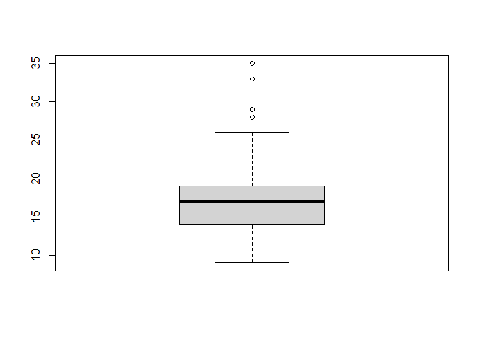

```
##      [,1]
## [1,]    9
## [2,]   14
## [3,]   17
## [4,]   19
## [5,]   26
```

```r
mpg1 <- read.csv("mpg1.csv")
boxplot(mpg1$cty)
boxplot(mpg1$cty)$stats          # 1개 변수의 통계값
```

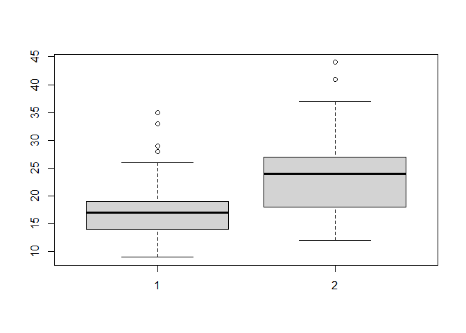

```
##      [,1] [,2]
## [1,]    9   12
## [2,]   14   18
## [3,]   17   24
## [4,]   19   27
## [5,]   26   37
```

```r
boxplot(mpg1$cty, mpg1$hwy)$stats# 복수변수의 통계값
```

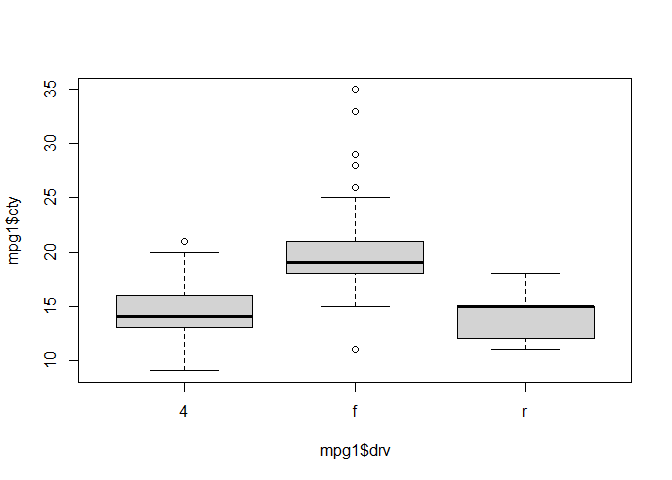

```
##      [,1] [,2] [,3]
## [1,]    9   15   11
## [2,]   13   18   12
## [3,]   14   19   15
## [4,]   16   21   15
## [5,]   20   25   18
```

```r
boxplot(mpg1$cty~mpg1$drv)$stats # 변수의의 범주별 통계값
```

- 극단치를 결측치 처리

```r
mpg1$cty <- ifelse(mpg1$cty>26|mpg1$cty<9, NA, mpg1$cty)
table(is.na(mpg1$cty))
```

```
##
## FALSE  TRUE
##   229     5
```

```r
mean(mpg1$cty, na.rm=T)
```

```
## [1] 16.55895
```

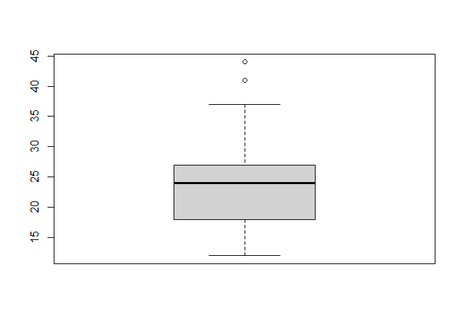

```
##      [,1]
## [1,]   12
## [2,]   18
## [3,]   24
## [4,]   27
## [5,]   37
```

```r
boxplot(mpg1$hwy)$stats
```

```r
mpg1$hwy <- ifelse(mpg1$hwy<12|mpg1$hwy>37, NA, mpg1$hwy)
mpg1 %>%
  filter(!is.na(hwy)) %>%
  group_by(trans) %>%
  summarise(m=mean(mpg1$hwy))
```

```
## # A tibble: 2 × 2
##   trans      m
##   <chr>  <dbl>
## 1 auto      NA
## 2 manual    NA
```

# Image Processing

```r
library(readxl)
library(ggplot2)
who_disease <- read_xlsx("who_disease.xlsx")
```

## 데이터 시각화는 데이터 가공 이후에 진행

## 기본 시각화

- ggplot() : 도화지
- aes(x= , y=) : x축, y축 그리기기
- 기본문법 : ggplot(데이터세트, aes(x= , y= )) + 그래프 종류

### 산점도 : x축 수치형(연속형)데이터, y축

수치형(연속형)데이터

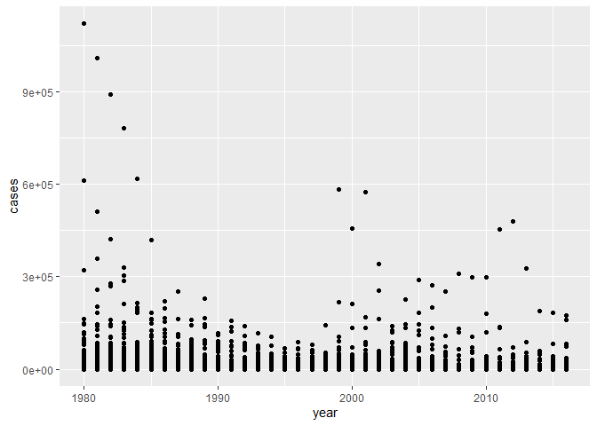

```r
ggplot(who_disease, aes(x = year, y = cases)) +
  geom_point()
```

### 막대그래프

- 원자료에서 범주별 크기를 구해서 그리기

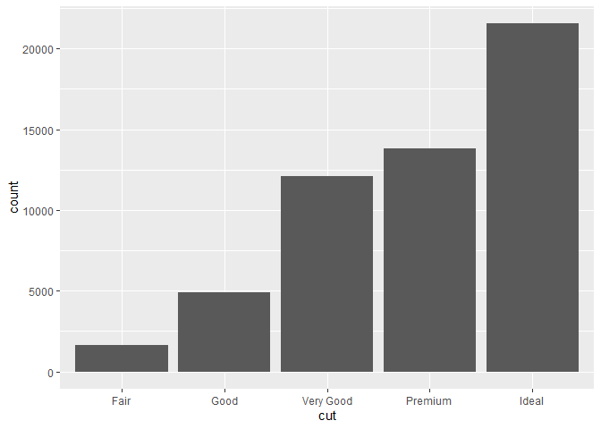

```r
ggplot(diamonds, aes(x=cut)) + geom_bar()
```

- y값 지정

```r
table(diamonds$cut)
```

```
##
##      Fair      Good Very Good   Premium     Ideal
##      1610      4906     12082     13791     21551
```

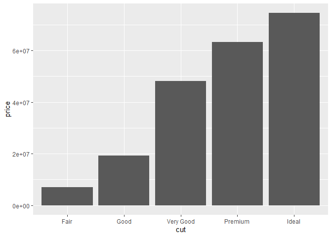

```r
ggplot(diamonds, aes(x=cut, y=price)) +
  geom_bar(stat = "identity")
```

- 범주별로 정해진 값을 토대로 그리기

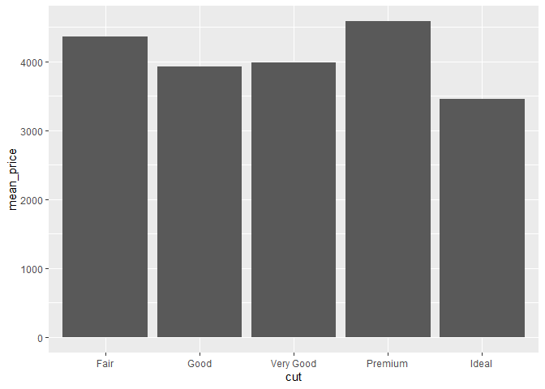

```r
cut_price <- diamonds %>%
  group_by(cut) %>%
  summarise(mean_price=mean(price))
# cut의 범주별 평균가격 구하기
ggplot(data=cut_price, aes(x=cut, y=mean_price)) +
  geom_col()
```

### 히스토그램

- 데이터의 분포가 어느구간에 몰려있는지 확인
- coord_flip() : x축이 복잡할때 사용

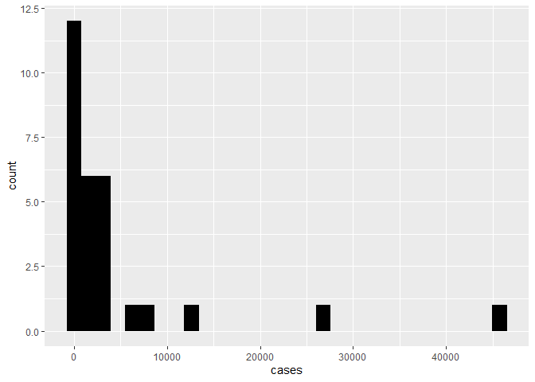

```r
library(dplyr)
data2 <- who_disease %>%
  filter(region == 'AMR',
         year == 1980,
         disease == 'pertussis',
         cases>0)
ggplot(data2, aes(x= cases)) +
  geom_histogram(fill = "654321")
```

## ggplot()정교하게 그리기

- 옵션명의 위치가 중요
- geom_point(옵션=““)
  - 설정한 색상으로 전부 변환
- ggplot(데이트세트, aes(x, y, ,옵션 = 컬럼명))
  - 컬럼별로 색상이 변환

### 산점도 그리기

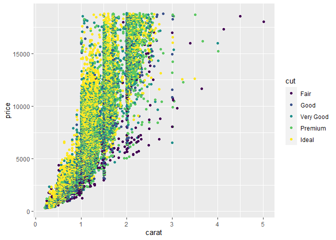

```r
ggplot(data = diamonds, aes(x=carat,
                            y=price,
                            col = cut)) +
  geom_point()
```

###막대그래프에 2개 범주 내용 반영

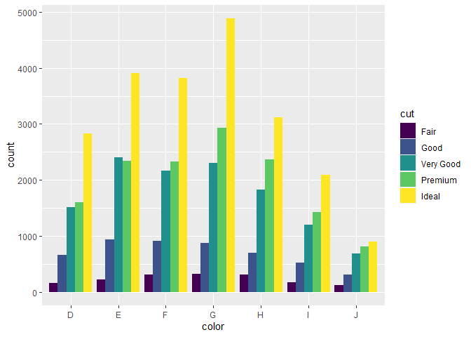

```r
ggplot(diamonds, aes(x=color,
                     fill=cut)) +
  geom_bar(position = "dodge")
```

- dodge는 비교, fill은 비율
- bar에만 있다

### 선 그래프에 2개 범주내용 반영

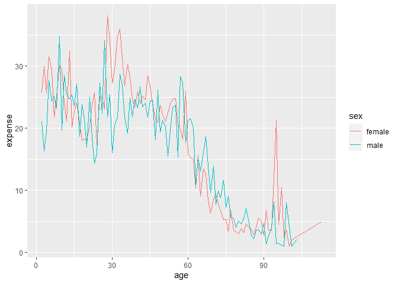

```r
leisur <- read.csv("leisure.csv")
ggplot(data= leisur, aes(x=age,
                         y=expense,
                         col=sex)) +
  geom_line()
```

### 막대그래프 순서변경

- reorder()

```r
mpg1 <- read.csv("mpg1.csv", stringsAsFactors = FALSE)
# 데이터가공
drv_hwy <- mpg1 %>%
  group_by(drv) %>%
  summarise(mean_hwy=mean(hwy))
```

- 기본그래프

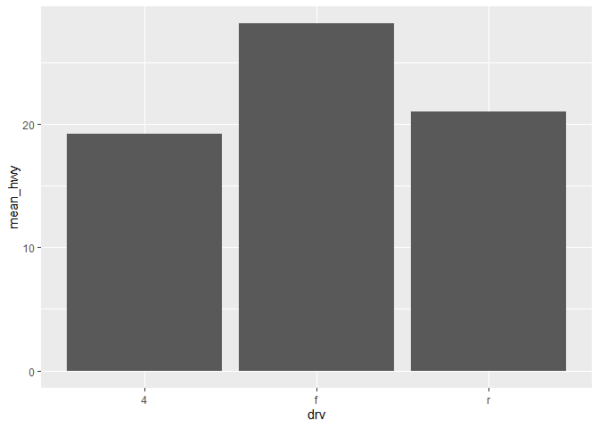

```r
ggplot(data=drv_hwy, aes(x=drv,
                         y=mean_hwy)) +
  geom_col()
```

- 오름차순

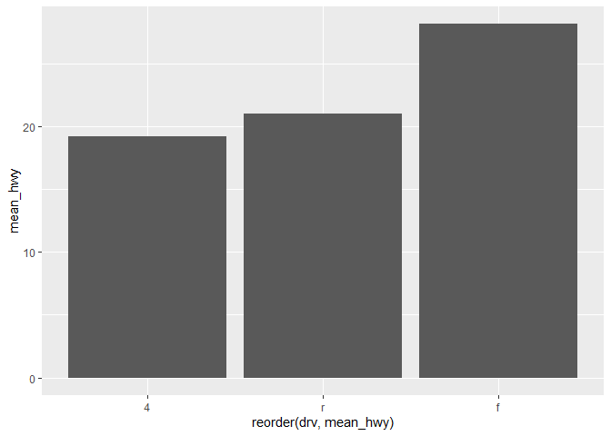

```r
ggplot(data=drv_hwy, aes(x=reorder(drv, mean_hwy),
                         y=mean_hwy)) +
  geom_col()
```

- 내림차순

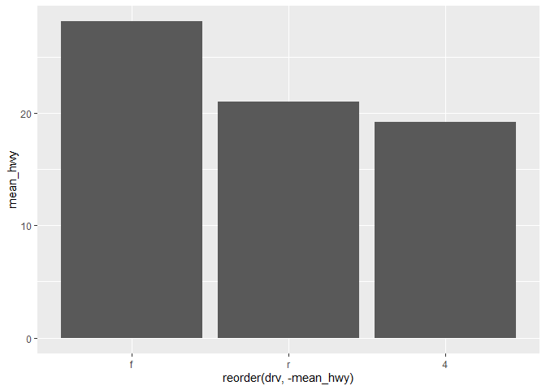

```r
ggplot(data=drv_hwy, aes(x=reorder(drv, -mean_hwy),
                         y=mean_hwy)) +
  geom_col()
```

- 옵션

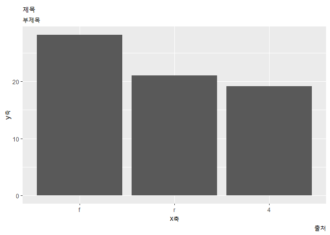

```r
ggplot(data=drv_hwy, aes(x=reorder(drv, -mean_hwy),
                         y=mean_hwy)) +
  geom_col() +
  labs(
    title = "제목",
    subtitle = "부제목",
    x="x축",
    y="y축",
    caption = "출처"
  )
```